# Receptor-noise limited modeling and JND-XYZ plotting

Alec Luro

October 6, 2020

All scripts are available in the *R_scripts* directory. Scripts should be run in the order of their names.

**Pipes `%>%`**

As you will see, I use a mix of direct inputs (e.g. `object_A <- function_A(x)`, and then `object_B <- function_B(object_A)`) and pipes `object_B <- x %>% function_A(.) %>% function_B(.)` throughout. Pipes can be convenient as they reduce the number of objects saved into the global environment by skipping through intermediate outputs and returning only the output generated following the last pipe. The object send by the pipe can be indicated using a period placeholder `.` but may also lack any placeholder at all as the pipe will always send the object to the next function’s object input.

# 1 R_scripts/01_import_and_clean_egg_spectra.R

This script imports the raw reflectance data, processes it, and saves it. The plot is added here in the notebook to demonstrate how to make a basic spectral reflectance plot.

## 1.1 Load packages and import the reflectance data

```r
library(tidyverse)
library(pavo)

## get egg reflectance spectra, smooth lines and add correction to negative values
iceland_murre_egg_spectra <-
  # import raw reflectance data from "data/" directory
  as.rspec(
    read_csv("data/iceland_murre_eggs_spectra.csv")
  ) %>%
  # process the reflectance spectra
  procspec(
    # smooth reflectance spectra data by a span of 0.25
    opt = "smooth",
    span = 0.25,
    # replace any negative reflectance values with 0
    fixneg = "zero"
  )
```

## 1.2 Plot cleaned reflectance spectra

Our murre egg reflectance data are now available as cleaned, smoothed spectra.

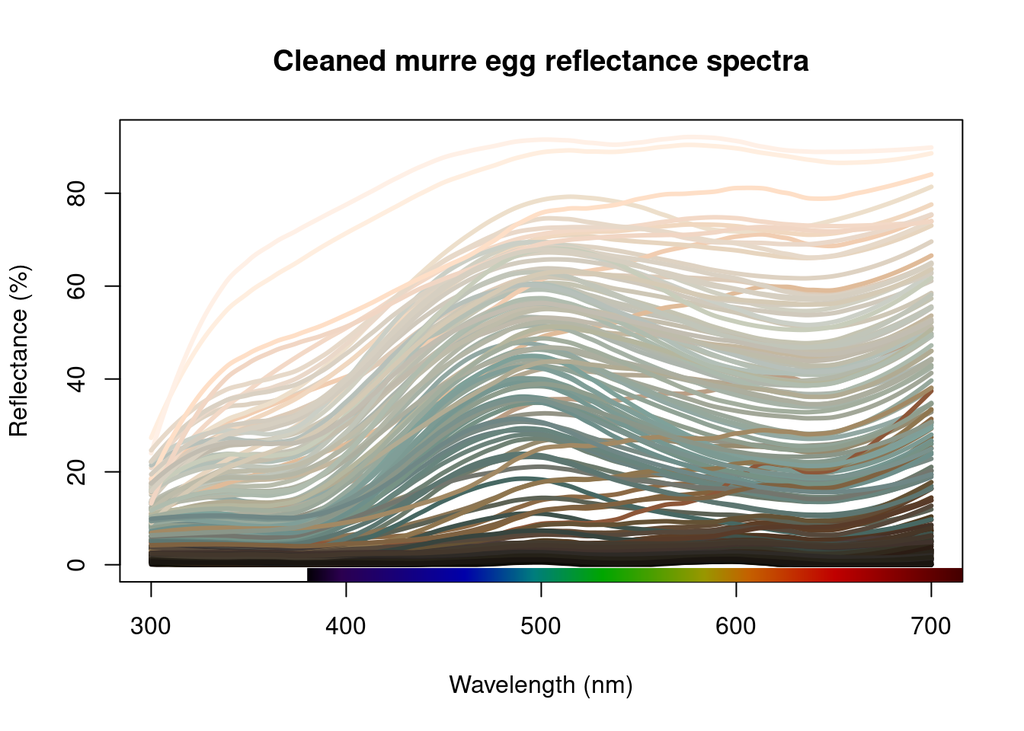

```r
plot(
  iceland_murre_egg_spectra,
  col = spec2rgb(iceland_murre_egg_spectra),
  lwd = 3,
  main = "Cleaned murre egg reflectance spectra")
```

## Save cleaned reflectance spectra

```r
write_csv(
  iceland_murre_egg_spectra,
  "data/iceland_murre_eggs_spectra_cleaned.csv"
)
```

# 2 R_scripts/02A_model_egg_JNDs.R

This script takes the cleaned murre egg reflectance data, subsets only spectra taken of egg backgrounds, coverts it to cone catch data using the peafowl visual system using `vismodel()`, calculates Just-noticeable differences (JNDs) using `coldist()`, coverts the JND values into relative coordinates amongst all egg backgrounds using `jnd2xyz()`, and plots the JND-XYZ coordinates.

## 2.1 Import cleaned murre egg reflectance data from “data/” directory

```r
# import cleaned murre egg reflectance data from "data/" directory
iceland_murre_egg_spectra <-
  read_csv(
      "data/iceland_murre_eggs_spectra_cleaned.csv"
    ) %>%
  as.rspec(.)
```

## 2.2 Subset only the egg background reflectance spectra

```r
# Get egg background color spectra only
egg_bkg_spectra <-
  subset(x = iceland_murre_egg_spectra, subset = "background")
```

## 2.3 Run a visual model using the peafowl visual system, get JND values, and save output

```r
egg_background_JNDs <-
  # pipe ("%>%" ) reflectance spectra data "vismodel" quantum catch calculation function
  egg_bkg_spectra %>%
      # Get photoreceptor cone catch, assuming Murres have a violet-sensitive SWS1 cone: https://doi.org/10.1098/rsbl.2009.0877
      vismodel(
        # The period "." is a placeholder for the piped object ("egg_bkg_spectra")
        rspecdata = .,
        # peafowl VS-type visual system
        visual = "pfowl",
        # bright mid-day sunlight irradiance spectrum
        illum = "D65",
        # ideal (flat grey) background which [murre egg] objects are viewed against
        bkg = "ideal",
        # ideal ocular media transmission (100% transmission across all light wavelengths)
        trans = "ideal",
        # use chicken double-cone for achromatic perception
        achromatic = "ch.dc",
        # apply a Von-Kries correction (i.e., assume color constancy in response to environmental lighting)
        vonkries = T,
        # set cone catches to relative to one another for receptor-noise limited modeling
        relative = F
      ) %>%
  # next, we pipe the calculated cone quantum catches into a "rename" column function to change VS cone name to "v" instead of "u"
      rename(
        .data = .,
        "v" = "u"
      ) %>%
  # finally, pipe the cone quantum catch values into RNL-modeling function "coldist"
      # get JND values from a receptor-noise limited model
      coldist(
        modeldata = .,
        # assume "neural" noise affects photoreception
        noise = "neural",
        # include calculation of achromatic JNDs
        achro = T,
        # set photoreceptor density ratios to (default Pekin robin): VS=1, MWS=2, LWS=2, double-cone=4
        n = c(1, 2, 2, 4),
        # set weber noise fraction to 0.1
        weber = 0.1,
        # use the LWS cone as the reference for the weber fraction
        weber.ref = "longest"
      )

# Save the calculated JND values as .csv
write_csv(egg_background_JNDs, path = "data/egg_background_JNDs.csv")

# Also save as .rds--this preserves the format that pavo uses for jndxyz(). jndxyz will NOT work if egg_background_JNDs is changed in any way (i.e., the .csv file won't work)
saveRDS(egg_background_JNDs, file = "data/egg_background_JNDs.rds")
```

## 2.4 Get JND XYZ coordinates

```r
# Get JND data
egg_background_JNDs <-
  read_rds(path = "data/egg_background_JNDs.rds")

# pipe JND data into jnd2xyz function
egg_background_JNDXYZ <-
  egg_background_JNDs %>%
      jnd2xyz(
        coldistres = .,
        rotate = T,
        # center the data onto the "mean" JND XYZ value
        center = T,
        rotcenter = "mean",
        # flip the axes by the LWS "l"and VS "v" cone coordinates
        ref1 = "l",
        ref2 = "v",
        # rotate the plot
        axis1 = c(1, 1, 0),
        axis2 = c(0, 0, 1)
      )

# Save the JND-XYZ values as .csv and .rds files
egg_background_JNDXYZ %>%
    rownames_to_column(., "egg_ID")%>%
    # rename the JND xyz value column names
    rename("JND_X" = "x", "JND_Y" = "y", "JND_Z" = "z", "Luminance" = "lum") %>%
  # output as a .csv file
  write_csv(., "data/egg_background_JNDXYZ.csv")

# Again, also save as .rds for other pavo functions to work
  saveRDS(egg_background_JNDXYZ, "data/egg_background_JNDXYZ.rds")
```

## 2.5 Make a 3D JND-XYZ plot

The plot generated here is for demonstration. A publication-quality pdf is made using the R-scripts. The lines necessary to generate a pdf of the figure are ignored here. Note that the violet cone is incorrectly labeled by “U” (“ultraviolet”). This is a bug in the `jndplot()` function that I have not found a solution for yet.

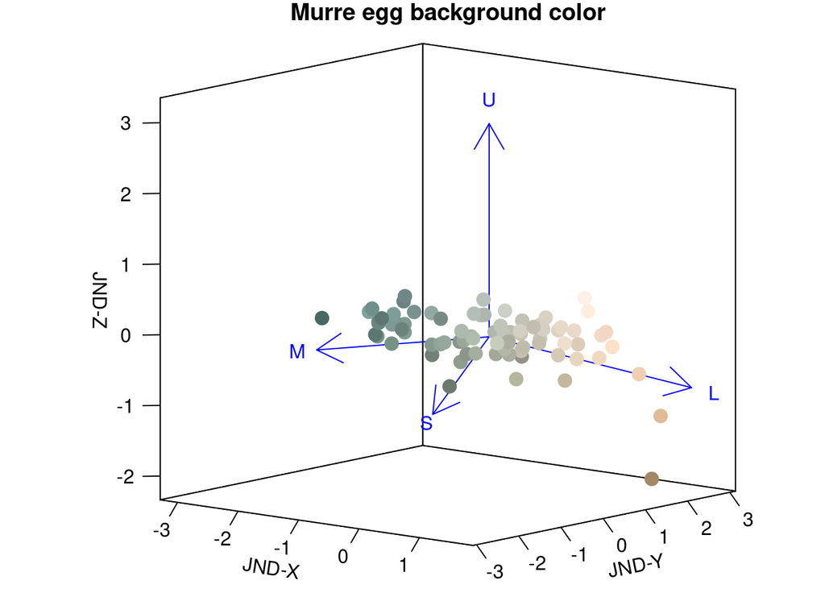

```r
# import JND-XYZ data
egg_background_JNDXYZ <-
    read_rds("data/egg_background_JNDXYZ.rds")

## Make a pdf save file in "figures/" directory named "jnd_xyz_plot_egg_background.pdf"
#pdf("figures/jnd_xyz_plot_egg_background.pdf")

# make 3D JND-XYZ plot
egg_background_JNDXYZ %>%
    jndplot(
      x = .,
      arrow = "relative",
      arrow.p = 2,
      arrow.col = "blue",
      # color points using RGG colors derived from egg bkg reflectance spectra
      col = spec2rgb(egg_bkg_spectra),
      margin = c(1, 3, 1, 0),
      cex = 1.5,
      square = F,
      xlab = "JND-X",
      ylab = "JND-Y",
      zlab = "JND-Z"
    )

# Add a title and position it 2 lines down from top of page
    title(
      main = "Murre egg background color"
    )
```

```r
# close the pdf file to save it
#dev.off()
```

# 3 R_scripts/02B_model_egg_JNDs.R

This script takes the cleaned murre egg reflectance data, splits egg background and egg spotting reflectance spectra into two items of a list, coverts them to cone catch data using the peafowl visual system using `vismodel()`, calculates Just-noticeable differences (JNDs) using `coldist()`, coverts the JND values into relative coordinates amongst all egg backgrounds using `jnd2xyz()`, and plots the JND-XYZ coordinates.

**The main difference between this script and the previous one (*R_scripts/02A_model_eggs_JND.R*) is the use of a `list()` to separate egg background and spotting spectra while keeping them as a single list object. This is especially useful in cases where the reflectance spectra data should be analyzed separately in RNL models `coldist()`–i.e. when spectra are to be compared within groups, but not between them. Different functions are applied to each list item using `lapply(x, function(x))`.**

## 3.1 Import reflectance data and create a list of egg background and spotting reflectance

Reflectance data as single dataset

```r
# Show original murre egg reflectance rspec data
iceland_murre_egg_spectra[1:3, 1:4]
```

```
##    wl IC1_background IC1_spot IC2_background
## 1 300       9.849917 3.930324       7.601096
## 2 301       9.825256 3.915711       7.675554
## 3 302       9.800961 3.901254       7.749126
```

Split list of reflectance dataset.

```r
# Separate spectra into list of length 2, one for egg "background" and one for egg spotting ("spot")
egg_spectra_split <-
  list(
    egg_background = subset(iceland_murre_egg_spectra, "background"),
    egg_spot = subset(iceland_murre_egg_spectra, "spot")
  )
# Show split list murre egg reflectance data
lapply(egg_spectra_split, function(x) x[1:3,1:4])
```

```
## $egg_background
##    wl IC1_background IC2_background IC3_background
## 1 300       9.849917       7.601096       13.44239
## 2 301       9.825256       7.675554       13.58724
## 3 302       9.800961       7.749126       13.73025
##
## $egg_spot
##    wl IC1_spot IC2_spot IC3_spot
## 1 300 3.930324 3.502752 2.617606
## 2 301 3.915711 3.504404 2.588931
## 3 302 3.901254 3.505964 2.560687
```

## 3.2 Run visual model on listed data

```r
egg_JNDs_split <-
  # pipe reflectance spectra data list into list-apply ("lapply") function
  egg_spectra_split %>%
  lapply(
    .,
    function(x) {
      # Get photoreceptor cone catch, assuming Murres have a violet-sensitive SWS1 cone: https://doi.org/10.1098/rsbl.2009.0877
      vismodel(
        x,
        # peafowl VS-type visual system
        visual = "pfowl",
        # bright mid-day sunlight irradiance spectrum
        illum = "D65",
        # ideal (flat grey) background which [murre egg] objects are viewed against
        bkg = "ideal",
        # ideal ocular media transmission (100% transmission across all light wavelengths)
        trans = "ideal",
        # use chicken double-cone for achromatic perception
        achromatic = "ch.dc",
        # apply a Von-Kries correction (i.e., assume color constancy in response to environmental lighting)
        vonkries = T,
        # set cone catches to relative to one another for receptor-noise limited modeling
        relative = F
      )
    }
  ) %>%
  # pipe the calculated cone quantum catches into a list-apply to change VS cone name to "v" instead of "u"
  lapply(
    .,
    function(x) {
      rename(
        x,
        "v" = "u"
      )
    }
    # pipe the cone quantum catch values into list-apply of RNL-modeling function "coldist"
  ) %>%
  lapply(
    .,
    function(x) {
      # get JND values from a receptor-noise limited model
      coldist(
        x,
        # assume "neural" noise affects photoreception
        noise = "neural",
        # include calculation of achromatic JNDs
        achro = T,
        # set photoreceptor density ratios to (default Pekin robin): VS=1, MWS=2, LWS=2, double-cone=4
        n = c(1, 2, 2, 4),
        # set weber noise fraction to 0.1
        weber = 0.1,
        # use the LWS cone as the reference for the weber fraction
        weber.ref = "longest"
      )
    }
    # pipe calculated JND values into list-apply function to get JND XYZ values
  ) %>%
  lapply(
    .,
    function(x) {
      jnd2xyz(
        x,
        rotate = T,
        # center the data onto the "mean" JND XYZ value
        center = T,
        rotcenter = "mean",
        # flip the axes by the LWS "l"and VS "v" cone coordinates
        ref1 = "l",
        ref2 = "v",
        # rotate the plot
        axis1 = c(1, 1, 0),
        axis2 = c(0, 0, 1)
      )
    }
  )
```

## 3.3 Make 3D JND-XYZ plots for both egg background and egg spotting

Again, the code to generate a pdf of the plot is ignored here.

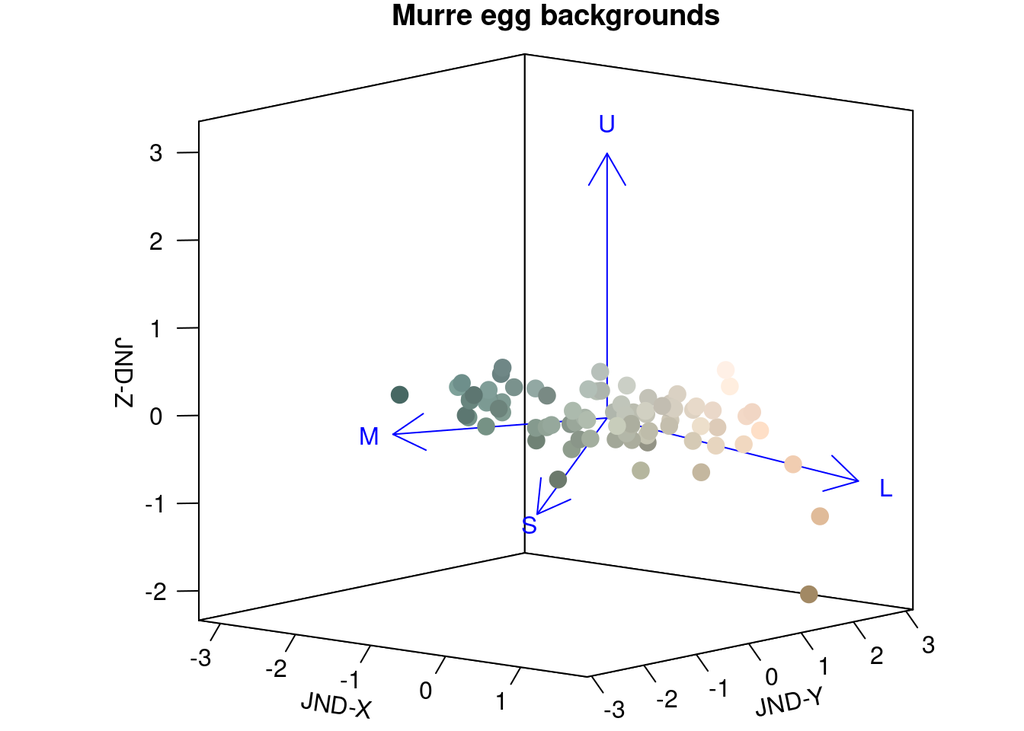

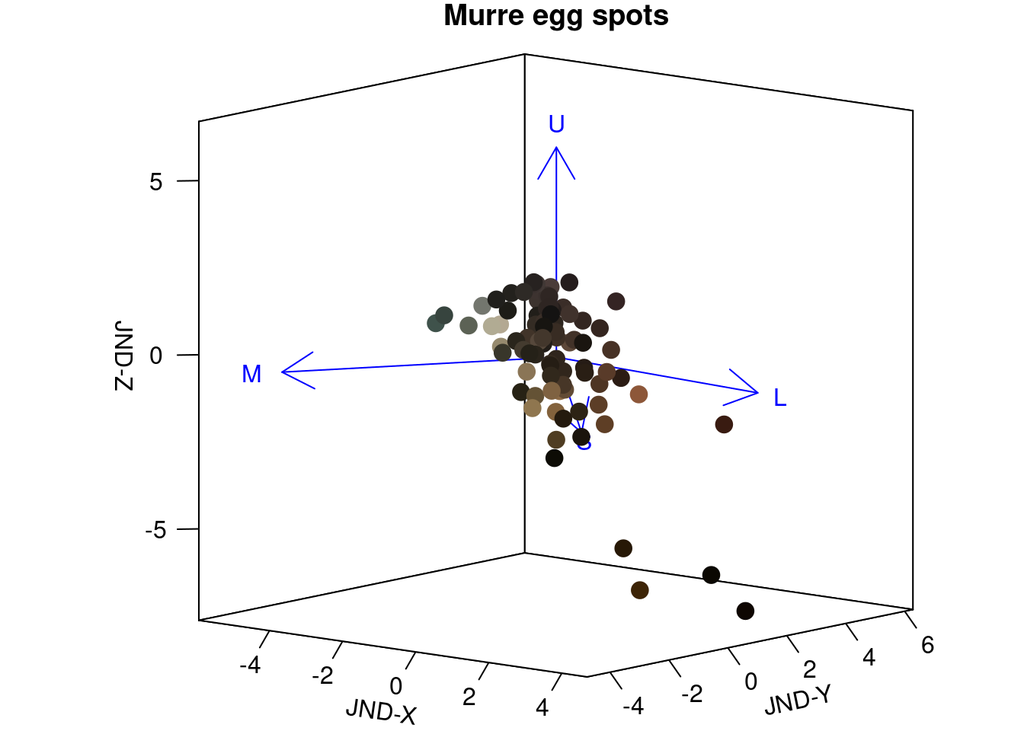

```r
## Make a pdf save file in "figures/" directory named "jnd_xyz_plots.pdf"
#pdf("figures/jnd_xyz_plots.pdf")

# multiple list-apply ("mapply") the jndplot function to both list items
mapply(
  function(x, y, z) {
    jndplot(
      x,
      arrow = "relative",
      arrow.p = 2,
      arrow.col = "blue",
      col = spec2rgb(y),
      margin = c(1, 3, 1, 0),
      cex = 1.5,
      square = F,
      xlab = "JND-X",
      ylab = "JND-Y",
      zlab = "JND-Z"
    )

    title(
      main = z
    )
  },
  # x = the list of JND dataframes (murre egg background and egg spotting JNDs)
  x = egg_JNDs_split,
  # y = the reflectance spectra data used to color the points in the 3D JND plot using "spec2rgb()"
  y = egg_spectra_split,
  # z = the titles for each 3D JND  plot
  z = c("Murre egg backgrounds", "Murre egg spots")
)
```

```r
# close the pdf file to save it
#dev.off()
```